# Reproducible Research: Peer Assessment 1

## Loading and preprocessing the data

**1. Load the data (i.e. read.csv())**

Unzip zip file.

```r
unzip("activity.zip")
time = timestamp()
```

```
## ##------ Sun Dec 20 01:48:35 2015 ------##
```

Load the data into R.

Assign dataset to the variable activity.

```r
activity <- read.csv("activity.csv")
```

**2. Process/transform the data (if necessary) into a format suitable for your analysis.**

Take a look at the data.

```r
str(activity)
```

```
## 'data.frame':    17568 obs. of  3 variables:
##  $ steps   : int  NA NA NA NA NA NA NA NA NA NA ...
##  $ date    : Factor w/ 61 levels "2012-10-01","2012-10-02",..: 1 1 1 1 1 1 1 1 1 1 ...
##  $ interval: int  0 5 10 15 20 25 30 35 40 45 ...
```

Change class of date variable from factor to POSIXct.

```r
activity$date <- as.POSIXct(activity$date)
class(activity$date)
```

```
## [1] "POSIXct" "POSIXt"
```

## What is mean total number of steps taken per day?

**1. Calculate the total number of steps taken per day.**

The total number of steps for each day are contained in the data frame ‘Steps’.

```r
Steps <- aggregate(activity$steps, list(activity$date), sum)
names(Steps) <- c("date", "StepsPerDay")
head(Steps)
```

```
##         date StepsPerDay
## 1 2012-10-01          NA
## 2 2012-10-02         126
## 3 2012-10-03       11352
## 4 2012-10-04       12116
## 5 2012-10-05       13294
## 6 2012-10-06       15420
```

**2. If you do not understand the difference between a histogram and a barplot, research the difference between them. Make a histogram of the total number of steps taken each day**

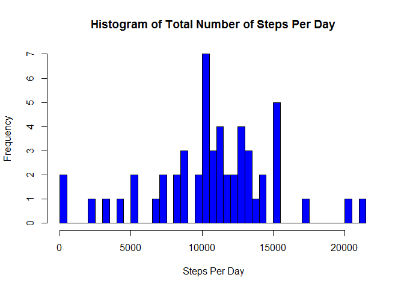

```r
hist(Steps$StepsPerDay, breaks = 50, xlim = c(0, max(Steps$StepsPerDay, na.rm = TRUE)+400), col = rgb(0,0,1), main = "Histogram of Total Number of Steps Per Day", xlab = "Steps Per Day")
```

**3. Calculate and report the mean and median of the total number of steps taken per day.**

The mean and median of the total number of steps taken per day are assigned to variables ‘meanSteps’ and ‘medianSteps’ respectively.

```r
meanSteps <- mean(Steps$StepsPerDay, na.rm = TRUE)
medianSteps <- median(Steps$StepsPerDay, na.rm = TRUE)
meanSteps: medianSteps
```

```
## [1] 10766.19 10765.19
```

The mean of the total number of steps taken per day is **10766.**  
The median of the total number of steps taken per day is **10765.**

## What is the average daily activity pattern?

**1. Make a time series plot (i.e. type = “l”) of the 5-minute interval (x-axis) and the average number of steps taken, averaged across all days (y-axis)**

‘activityPat’ is a data frame containing the mean number of steps for each interval.

```r
activityPat <- aggregate(activity$steps, list(activity$interval), mean, na.rm = TRUE)
names(activityPat) <- c("interval", "average")
head(activityPat)
```

```
##   interval   average
## 1        0 1.7169811
## 2        5 0.3396226
## 3       10 0.1320755
## 4       15 0.1509434
## 5       20 0.0754717
## 6       25 2.0943396
```

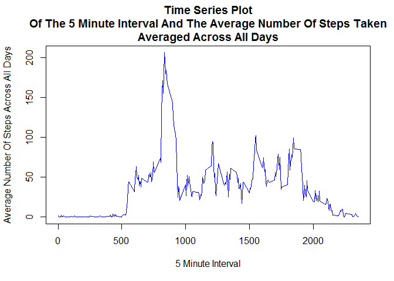

```r
plot(activityPat$interval, activityPat$average, type = "l", col = "blue", main = "Time Series Plot\nOf The 5 Minute Interval And The Average Number Of Steps Taken\nAveraged Across All Days",  xlab = "5 Minute Interval", ylab = "Average Number Of Steps Across All Days")
```

**2. Which 5-minute interval, on average across all the days in the dataset, contains the maximum number of steps?**  
The 5 minute interval containing the maximum number of steps is assigned to the variable ‘maxInterval’

```r
m <- which.max(activityPat$average)
maxInterval <- activityPat[m,1]
maxInterval
```

```
## [1] 835
```

The 5 minute interval that contains the maximum number of steps is **835**

## Imputing missing values

Note that there are a number of days/intervals where there are missing values (coded as NA). The presence of missing days may introduce bias into some calculations or summaries of the data.

**1. Calculate and report the total number of missing values in the dataset (i.e. the total number of rows with NAs)**

```r
total_NAs <- nrow(activity[is.na(activity),])
```

The total number of missing values in the datset is **2304**

**2. Devise a strategy for filling in all of the missing values in the dataset. The strategy does not need to be sophisticated. For example, you could use the mean/median for that day, or the mean for that 5-minute interval, etc.**

‘activityPat’ contains the averages for each interval accross all days.  
I will use activityPat$average to impute missing values.

**3. Create a new dataset equal to the original dataset with missing data filled in.**

Assign copy of original dataset ‘activity’ to a new data frame called ‘activity_new’.

```r
activity_new <- activity
```

Impute missing values

```r
activityPat$average <- as.integer(activityPat$average)
for (i in 1 : nrow(activity_new)) {
        if (is.na(activity_new$steps[i]) == FALSE) {
                activity_new$steps[i] = activity_new$steps[i]
                } else {
            for (j in 1: nrow(activityPat)) {
                    if (activity_new$interval[i] == activityPat$interval[j]) {
                            activity_new$steps[i] = activityPat$average[j]
                    }
            }
                }
}
```

Check ‘activity_new’ for missing values, to see that all NAs have been imputed.  
The variable ‘Rowstotal’ is the nomber of rows and ‘NAstotal’ is the number of NAs.

```r
Rowstotal <- nrow(activity_new)
NAstotal <- nrow(activity_new[is.na(activity_new),])
Rowstotal
```

```
## [1] 17568
```

```r
NAstotal
```

```
## [1] 0
```

There are **17568** rows and **0** NAs in the the data frame with imputed values.  
All missing values have been filled in.

**4. Make a histogram of the total number of steps taken each day and Calculate and report the mean and median total number of steps taken per day. Do these values differ from the estimates from the first part of the assignment? What is the impact of imputing missing data on the estimates of the total daily number of steps?**

** Breakdown of question 4.**

1. Plot histogram. Steps_new is a data frame containing the total number of steps for each day.

```r
Steps_new <- aggregate(activity_new$steps, list(activity_new$date), sum)
names(Steps_new) <- c("date", "StepsPerDay")
head(Steps_new)
```

```
##         date StepsPerDay
## 1 2012-10-01       10641
## 2 2012-10-02         126
## 3 2012-10-03       11352
## 4 2012-10-04       12116
## 5 2012-10-05       13294
## 6 2012-10-06       15420
```

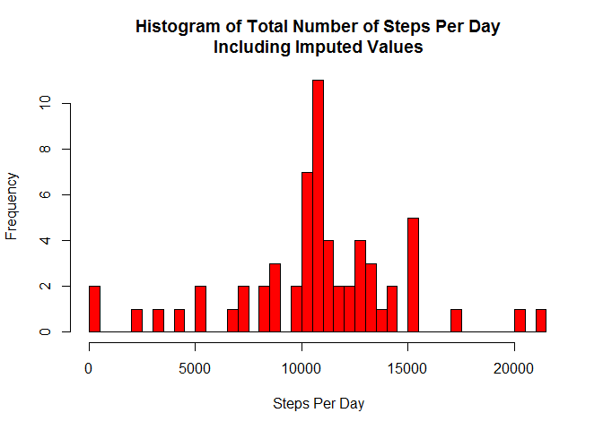

```r
hist(Steps_new$StepsPerDay, breaks = 50, xlim = c(0, max(Steps_new$StepsPerDay)+400), col = rgb(1,0,0), main = "Histogram of Total Number of Steps Per Day\nIncluding Imputed Values", xlab = "Steps Per Day")
```

2. Calculate and report on mean and median total number of steps taken per day.

```r
mean_Steps_new <- as.integer(mean(Steps_new$StepsPerDay))
median_Steps_new <- median(Steps_new$StepsPerDay)
mean_Steps_new
```

```
## [1] 10749
```

```r
median_Steps_new
```

```
## [1] 10641
```

The mean total number of steps taken per day is **10749**  
The median total number of steps taken per day is **10641**

3. Do these values differ from the estimates from the first part of the assignment?

```r
mean_diff <- as.integer(mean(Steps_new$StepsPerDay) - mean(Steps$StepsPerDay, na.rm = TRUE))
median_diff <- median(Steps_new$StepsPerDay) - median(Steps$StepsPerDay, na.rm = TRUE)
if(mean_diff > 0) {meanPosNeg <- "greater than"
}else {meanPosNeg <- "less than"}
if(median_diff > 0) {medianPosNeg <- "greater than"
}else {medianPosNeg <- "less than"}
```

The mean is **16 steps less than** the estimate from the first part of assignment.  
The median is **124 steps less than** the estimate from the first part of assignment.

4. What is the impact of imputing missing data on the estimates of the total daily number of steps? To better answer this I plotted the histograms side by side and showing the mean. I calculated the number of days that had missing data. I also calculated the number of steps imputed for each day.

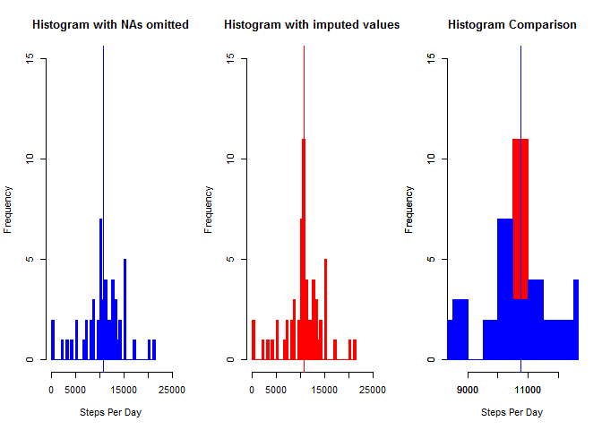

```r
par(mfrow = c(1,3))
hist(Steps$StepsPerDay, xlim = c(0,25000), ylim = c(0,15), border = "blue", breaks = 50,  col = rgb(0,0,1), main = "Histogram with NAs omitted", xlab = "Steps Per Day")
abline(v = mean(Steps$StepsPerDay, na.rm = TRUE), col = "blue")
hist(Steps_new$StepsPerDay, xlim = c(0, 25000), ylim = c(0,15), border = "red", breaks = 50, col = rgb(1,0,0), main = "Histogram with imputed values", xlab = "")
abline(v = mean(Steps_new$StepsPerDay), col ="red")

hist(Steps_new$StepsPerDay, xlim = c(8500, 12500), ylim = c(0,15), border = "red", breaks = 50, col = rgb(1,0,0), main = "", xlab = "")
abline(v = mean(Steps_new$StepsPerDay), col ="red")
par(new = TRUE)
hist(Steps$StepsPerDay, xlim = c(8500, 12500), ylim = c(0,15), border = "blue", breaks = 50,  col = rgb(0,0,1), main = "Histogram Comparison", xlab = "Steps Per Day")
abline(v = mean(Steps$StepsPerDay, na.rm = TRUE), col = "blue")
```

Extract the number of days for which values were imputed. Calculate the total number steps imputed each day.

```r
activityNA <- subset(activity, is.na(steps) == TRUE)
activityNA[,3] <- NULL
activityNA <- unique(activityNA)
DailyTotalImp <- sum(activityPat$average)
numberDays <- nrow(activityNA)
numberDays
```

```
## [1] 8
```

```r
DailyTotalImp
```

```
## [1] 10641
```

There are **8** days for which values are imputed.  
The total number of steps imputed for each of these days is **10641**.

**The increase in the data in the dataset with imputed values caused the mean and the median to move a little to the left. All the imputed values are close to the mean. Outside the central area the imputed data has no effect. (Note that the means on the combined histogram are so close that they are superimposed.)**

## Are there differences in activity patterns between weekdays and weekends?

**For this part the weekdays() function may be of some help here. Use the dataset with the filled-in missing values for this part.**

**1. Create a new factor variable in the dataset with two levels  “weekday” and “weekend” indicating whether a given date is a weekday or weekend day.**

Create factor variable ‘day’ with 2 levels ‘weekday’ and ‘weekend’. We have the dataset ‘activity_new’, which vae the imputed missing values.

Use ‘rminer’ package to change levels.

```r
activity_new$day <- as.factor(weekdays(activity_new$date))
str(activity_new)
```

```
## 'data.frame':    17568 obs. of  4 variables:
##  $ steps   : int  1 0 0 0 0 2 0 0 0 1 ...
##  $ date    : POSIXct, format: "2012-10-01" "2012-10-01" ...
##  $ interval: int  0 5 10 15 20 25 30 35 40 45 ...
##  $ day     : Factor w/ 7 levels "Friday","Monday",..: 2 2 2 2 2 2 2 2 2 2 ...
```

```r
library(rminer)
activity_new$day <- delevels(activity_new$day, c("Monday", "Tuesday", "Wednesday", "Thursday",  "Friday"), label = "weekday")
activity_new$day <- delevels(activity_new$day, c("Saturday", "Sunday"), label = "weekend")
str(activity_new)
```

```
## 'data.frame':    17568 obs. of  4 variables:
##  $ steps   : int  1 0 0 0 0 2 0 0 0 1 ...
##  $ date    : POSIXct, format: "2012-10-01" "2012-10-01" ...
##  $ interval: int  0 5 10 15 20 25 30 35 40 45 ...
##  $ day     : Factor w/ 2 levels "weekday","weekend": 1 1 1 1 1 1 1 1 1 1 ...
```

**2. Make a panel plot containing a time series plot (i.e. type = “l”) of the 5-minute interval (x-axis) and the average number of steps taken, averaged across all weekday days or weekend days (y-axis). See the README file in the GitHub repository to see an example of what this plot should look like using simulated data.**

Use ‘ggplot2’ package to create panel plot with ggplot() function.

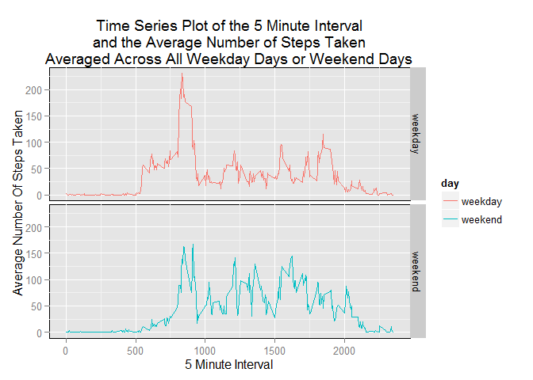

```r
library(ggplot2)

activity_Wday_Wend <- aggregate(activity_new$steps, list(activity_new$interval, activity_new$day), mean)
names(activity_Wday_Wend) <- c("interval", "day", "average")

g <-  ggplot(activity_Wday_Wend , aes(interval, average))

g + geom_line(aes(group = day, color = day)) + facet_grid(day ~ .) +
        labs(title = "Time Series Plot of the 5 Minute Interval
and the Average Number of Steps Taken
Averaged Across All Weekday Days or Weekend Days") +
        labs(x = "5 Minute Interval", y = "Average Number Of Steps Taken") +
        theme(panel.background = element_rect(color = "black"))
```